# Final Project:

### Manipulate data-frame with Pyspark and train a ML/DL model all using Pyspark

Purpose:

- I will be performing analysis and training a Machine Learning model using Pyspark
- I want to compare the difference with using Pyspark by using the same data I used in DS 2.1 for Body Mass Index

[figure not shown]

## Recap from DS 2.1:

- Used pandas to perform data analysis, matplotlib and seaborn for data visualization, scikit-learn for ML
- Data included: Gender, Height, Weight, Index
- I added a column for Category by converting the Index Number to represent the following:
  - Extremely Weak, Weak, Normal, Overweight, Obesity, Extreme Obesty
- I tested the model on myself which categorized me as: 'Unhealthy' but the score of 21.58 is in the 'Healthy' range

### Index Types:

```
- 0 - Extremely Weak
- 1 - Weak
- 2 - Normal
- 3 - Overweight
- 4 - Obesity
- 5 - Extreme Obesity
```

Index Types from the Dataset are compared to those defined by the World Health Organization (WHO) Table 1. Nutritional status

### BMI Nutritional status:

**Underweight:** Below 18.5

**Normal weight:** 18.5–24.9

**Pre-obesity:** 25.0–29.9

**Obesity class I:** 30.0–34.9

**Obesity class II:** 35.0–39.9

**Obesity class III:** Above 40

### NOTE:

- It is unclear from the data source which index type correlates to which type according to WHO.

Source: http://www.euro.who.int/en/health-topics/disease-prevention/nutrition/a-healthy-lifestyle/body-mass-index-bmi

### How to Calculate BMI:

[figure not shown]

For more information about BMI: https://en.wikipedia.org/wiki/Body_mass_index

# Part 1: Using Pandas for Data Analysis

```python
import pandas as pd

df = pd.read_csv('Datasets/Gender_Height_Weight.csv')
df.head()
```

|  | Gender | Height | Weight | Index |
| --- | --- | --- | --- | --- |
| 0 | Male | 174 | 96 | 4 |
| 1 | Male | 189 | 87 | 2 |
| 2 | Female | 185 | 110 | 4 |
| 3 | Female | 195 | 104 | 3 |
| 4 | Male | 149 | 61 | 3 |

```python
# Convert the data from index column into category type

def convert_index_to_category(df):
    if df['Index'] == 0:
        return 'Extremely Weak'
    elif df['Index'] == 1:
        return 'Weak'
    elif df['Index'] == 2:
        return 'Normal'
    elif df['Index'] == 3:
        return 'Overweight'
    elif df['Index']== 4:
        return 'Obesity'
    elif df['Index'] == 5:
        return 'Extreme Obesity'

df['Category'] = df.apply(convert_index_to_category, axis=1)  # Add a new column
df.head()
```

|  | Gender | Height | Weight | Index | Category |
| --- | --- | --- | --- | --- | --- |
| 0 | Male | 174 | 96 | 4 | Obesity |
| 1 | Male | 189 | 87 | 2 | Normal |
| 2 | Female | 185 | 110 | 4 | Obesity |
| 3 | Female | 195 | 104 | 3 | Overweight |
| 4 | Male | 149 | 61 | 3 | Overweight |

```python
# Rename Columns

df.rename(columns = {'Height' : 'Height (cm)', 'Weight' : ' Weight (kg)'})
```

|  | Gender | Height (cm) | Weight (kg) | Index | Category |
| --- | --- | --- | --- | --- | --- |
| 0 | Male | 174 | 96 | 4 | Obesity |
| 1 | Male | 189 | 87 | 2 | Normal |
| 2 | Female | 185 | 110 | 4 | Obesity |
| 3 | Female | 195 | 104 | 3 | Overweight |
| 4 | Male | 149 | 61 | 3 | Overweight |
| ... | ... | ... | ... | ... | ... |
| 495 | Female | 150 | 153 | 5 | Extreme Obesity |
| 496 | Female | 184 | 121 | 4 | Obesity |
| 497 | Female | 141 | 136 | 5 | Extreme Obesity |
| 498 | Male | 150 | 95 | 5 | Extreme Obesity |
| 499 | Male | 173 | 131 | 5 | Extreme Obesity |

500 rows × 5 columns

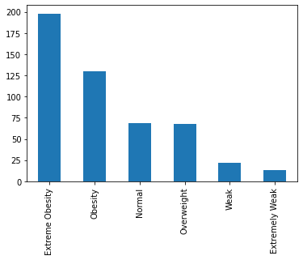

```python
# A visual of the values in each category

df['Category'].value_counts().plot(kind='bar')
```

```python
# The numbers for each category

df['Category'].value_counts()
```

```
Extreme Obesity    198
Obesity            130
Normal              69
Overweight          68
Weak                22
Extremely Weak      13
Name: Category, dtype: int64
```

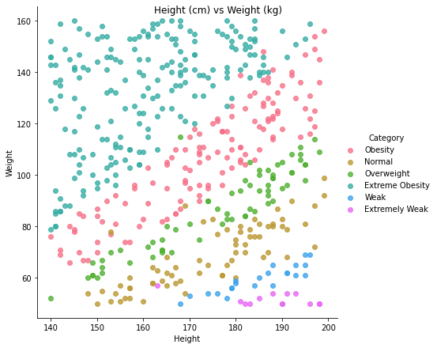

```python
# Show plot of the different categories

import seaborn as sns
import matplotlib as plt


sns.lmplot( x='Height', y='Weight', data=df,
           fit_reg=False,
           hue='Category',
           legend=True,
           palette='husl',
           size = 6,
           aspect = 1,
          ).fig.suptitle("Height (cm) vs Weight (kg)")
```

```python
# Change and create a column for the value of male to 1 and female to 0

def convert_gender_to_num(x):
    if x['Gender'] == 'Male':
        return 1
    elif x['Gender'] == 'Female':
        return 0
df['Gender Number'] = df.apply(convert_gender_to_num, axis=1)
df.head()
```

|  | Gender | Height | Weight | Index | Category | Gender Number |
| --- | --- | --- | --- | --- | --- | --- |
| 0 | Male | 174 | 96 | 4 | Obesity | 1 |
| 1 | Male | 189 | 87 | 2 | Normal | 1 |
| 2 | Female | 185 | 110 | 4 | Obesity | 0 |
| 3 | Female | 195 | 104 | 3 | Overweight | 0 |
| 4 | Male | 149 | 61 | 3 | Overweight | 1 |